# FinalReport

## Team Members

[figure not shown]

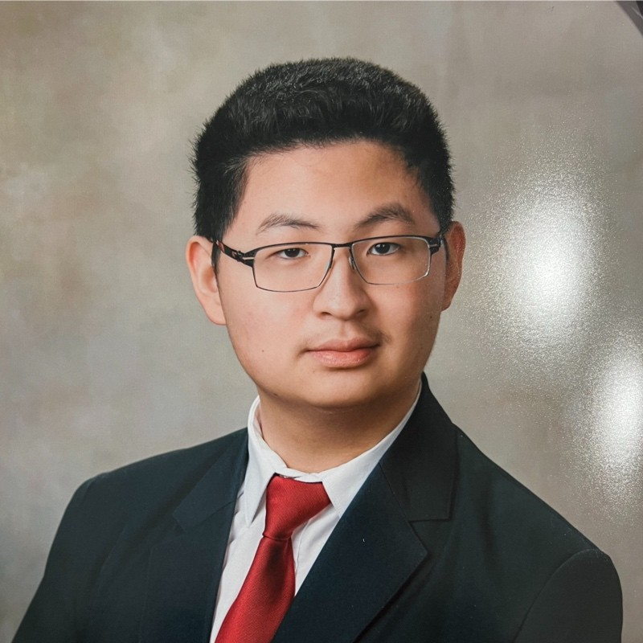

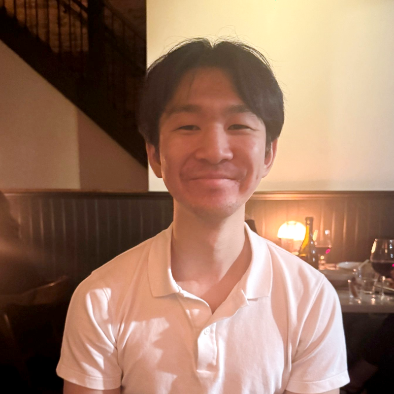

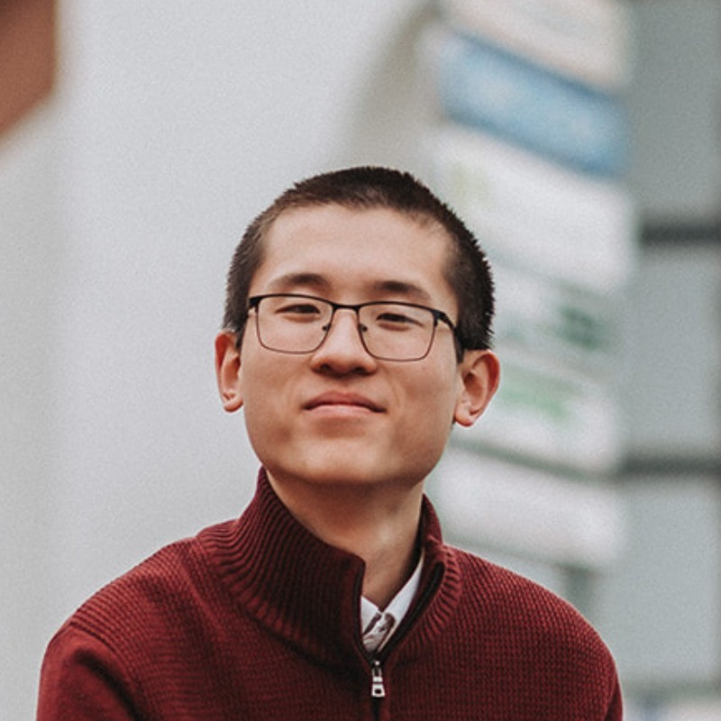

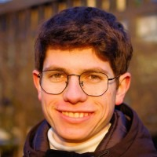

**[Riccardo Ferrari](https://www.linkedin.com/in/riccardo-ferrari-2929b722a/)**  
Financial Analyst

**[Mike Ye](https://www.linkedin.com/in/mike-ye-460923270/)**  
Team Lead

**Daniel Myung**  
Data Scientist

**[Steven Liu](https://www.linkedin.com/in/steven-liu-554652244/)**  
Communication Specialist

**[Andrea Demelas](https://www.linkedin.com/in/andreademelas/)**  
Business Analyst

# Executive Summary

414 Company’s call center currently faces several challenges. Call center associates frequently face abusive customers, which leads to extreme employee turnover. Many quit within days, driving high training costs of $1000 per associate. The call center utilizes a blanket strategy in regards to outreach, with standardized talking-points from HR.

We use data-forward methodologies to assess customer patterns, recommending a targeted approach to achieve beyond break-even profitability. Our approach utilizes supervised and unsupervised algorithmic learning models to calculate profitable target segments, comparing the results to blanket-calling. We demonstrate our work with each type of algorithm to propose the most profitable strategy.

# Background

# Data Exploration

We began by taking a deep dive into our data.

```
##       age                 job            marital
##  Min.   :17.00   admin.     :10422   divorced: 4612
##  1st Qu.:32.00   blue-collar: 9254   married :24928
##  Median :38.00   technician : 6743   single  :11568
##  Mean   :40.02   services   : 3969   unknown :   80
##  3rd Qu.:47.00   management : 2924
##  Max.   :98.00   retired    : 1720
##                  (Other)    : 6156
##                education        default         housing           loan
##  university.degree  :12168   no     :32588   no     :18622   no     :33950
##  high.school        : 9515   unknown: 8597   unknown:  990   unknown:  990
##  basic.9y           : 6045   yes    :    3   yes    :21576   yes    : 6248
##  professional.course: 5243
##  basic.4y           : 4176
##  basic.6y           : 2292
##  (Other)            : 1749
##       contact          month       day_of_week    campaign         previous
##  cellular :26144   may    :13769   fri:7827    Min.   : 1.000   Min.   :0.000
##  telephone:15044   jul    : 7174   mon:8514    1st Qu.: 1.000   1st Qu.:0.000
##                    aug    : 6178   thu:8623    Median : 2.000   Median :0.000
##                    jun    : 5318   tue:8090    Mean   : 2.568   Mean   :0.173
##                    nov    : 4101   wed:8134    3rd Qu.: 3.000   3rd Qu.:0.000
##                    apr    : 2632               Max.   :56.000   Max.   :7.000
##                    (Other): 2016
##         poutcome      emp.var.rate      cons.price.idx  cons.conf.idx
##  failure    : 4252   Min.   :-3.40000   Min.   :92.20   Min.   :-50.8
##  nonexistent:35563   1st Qu.:-1.80000   1st Qu.:93.08   1st Qu.:-42.7
##  success    : 1373   Median : 1.10000   Median :93.75   Median :-41.8
##                      Mean   : 0.08189   Mean   :93.58   Mean   :-40.5
##                      3rd Qu.: 1.40000   3rd Qu.:93.99   3rd Qu.:-36.4
##                      Max.   : 1.40000   Max.   :94.77   Max.   :-26.9
##
##    euribor3m      nr.employed     y         was_contacted
##  Min.   :0.634   Min.   :4964   no :36548   Min.   :0.00000
##  1st Qu.:1.344   1st Qu.:5099   yes: 4640   1st Qu.:0.00000
##  Median :4.857   Median :5191               Median :0.00000
##  Mean   :3.621   Mean   :5167               Mean   :0.03678
##  3rd Qu.:4.961   3rd Qu.:5228               3rd Qu.:0.00000
##  Max.   :5.045   Max.   :5228               Max.   :1.00000
##
```

**Current profitability**

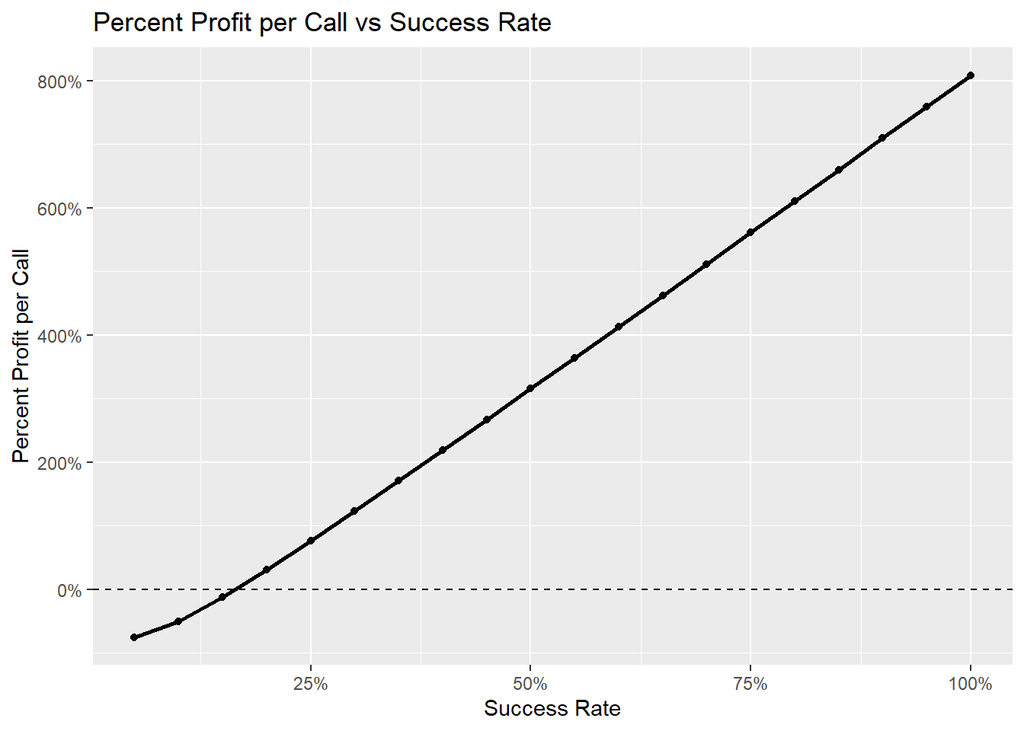

We set out to find a profitability benchmark. For our profitability calculations, we assume the following as per the specifications:

- Each call has a static cost of 1 dollar
- Employees have a 1000 dollar training cost, with on average 1000 calls before quitting, increasing by 100 calls per 1% additional call success above the current 11% and vice versa.
- The revenue from a successful call is 10 dollars

However, this is not the case with our firm currently. This is where our profitability currently stands:

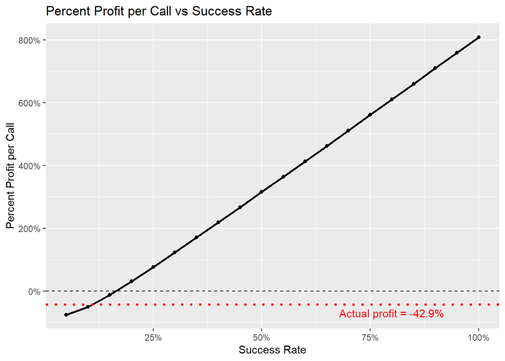

We believe we can achieve this by clustering our customer base into several groups, and only focus on calling those with a >20% succuss rate. We can also make a prediction model to determine if a call meets the critieria before we make the call to maximize our profit. We will explore both of these approachs and their predicted outcomes in the following sections.

For now, we seek to understand which of the factors influence a call’s success rate the most in an attempt in increase our call success rates:

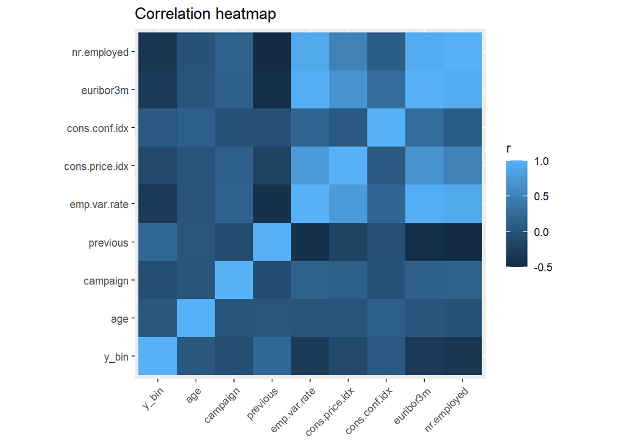

We see from the heatmap weak correlation between a call’s success rate and the other numerical variables. No relationship as a whole is large enough to be easily visible in the graph.

Despite the groups as a whole not having significant correlation with success rate, there still exists significant factors within each attribute that influences it. One of the most significant relationship we have found is between age and call success rate:

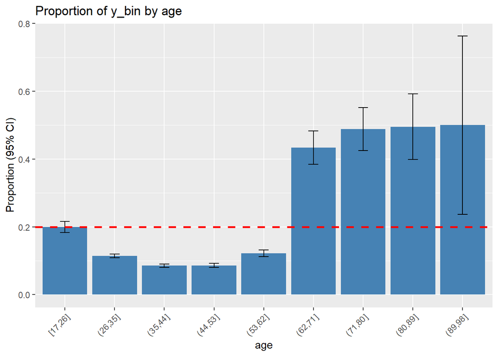

```
## # A tibble: 9 × 6
## # Rowwise:
##   group_var     n   yes      p  lower  upper
##   <fct>     <int> <dbl>  <dbl>  <dbl>  <dbl>
## 1 [17,26]    2364   471 0.199  0.183  0.216
## 2 (26,35]   14149  1618 0.114  0.109  0.120
## 3 (35,44]   11741  1001 0.0853 0.0803 0.0905
## 4 (44,53]    8020   689 0.0859 0.0799 0.0923
## 5 (53,62]    4139   504 0.122  0.112  0.132
## 6 (62,71]     406   176 0.433  0.385  0.483
## 7 (71,80]     250   122 0.488  0.425  0.552
## 8 (80,89]     109    54 0.495  0.399  0.592
## 9 (89,98]      10     5 0.5    0.237  0.763
```

We have calculated a 95% confidence interval for the true value of each subgroup of the age data as indicated by the black bars on the graph. A confidence interval above the red break-even line indicates that the subgroup is profitable to call.

## Key Attributes

We see that **older customers** (>62) has over 40% call success rate. This makes them highly valuable customers we should prioritize. The other age bracket of interest is from 17-26, with a call success rate confidence interval including the break-even threshold of 20%. We should closely monitor this group to assess future potential of conversion into profitable customers.

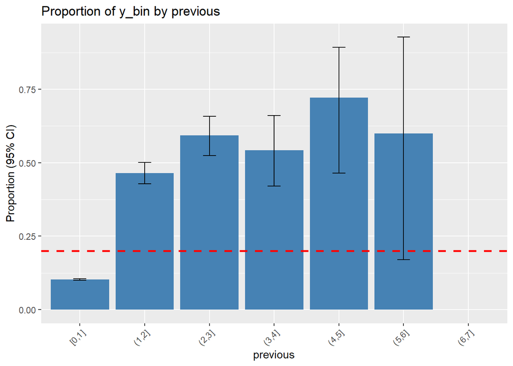

```
## # A tibble: 7 × 6
## # Rowwise:
##   group_var     n   yes     p   lower  upper
##   <fct>     <int> <dbl> <dbl>   <dbl>  <dbl>
## 1 [0,1]     40124  4108 0.102  0.0994  0.105
## 2 (1,2]       754   350 0.464  0.428   0.501
## 3 (2,3]       216   128 0.593  0.524   0.658
## 4 (3,4]        70    38 0.543  0.420   0.661
## 5 (4,5]        18    13 0.722  0.464   0.893
## 6 (5,6]         5     3 0.6    0.170   0.927
## 7 (6,7]         1     0 0     NA      NA
```

**Repeated previous contact** also seems to be a significant contributor to the success rate. There seem to be a high correlation between multiple previous calls and success rate. This does not support repeatably calling the same unenthusiastic customers; rather, we should divert resources to target repeat customers or enthusatic customers.

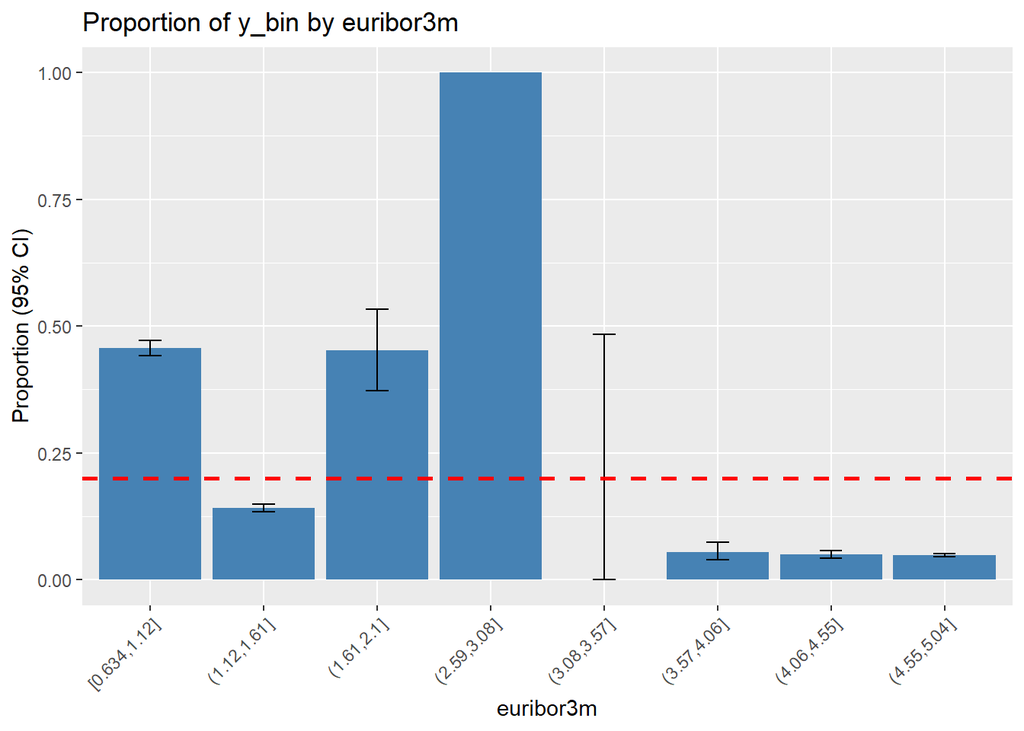

## Clustering

Next, we deploy clustering, an unsupervised machine learning technique, to create nuanced customer segments within the 414 Company’s telemarketing dataset to achieve profitability. Specifically, we use the K-means algorithm, which partitions data-point observations into groups through an iterative approach. In short, K-means allows us identify segments of customers, resulting in nuanced customer personas to target.

```
## 'data.frame':    41188 obs. of  20 variables:
##  $ age           : int  56 57 37 40 56 45 59 41 24 25 ...
##  $ job           : Factor w/ 12 levels "admin.","blue-collar",..: 4 8 8 1 8 8 1 2 10 8 ...
##  $ marital       : Factor w/ 4 levels "divorced","married",..: 2 2 2 2 2 2 2 2 3 3 ...
##  $ education     : Factor w/ 8 levels "basic.4y","basic.6y",..: 1 4 4 2 4 3 6 8 6 4 ...
##  $ default       : Factor w/ 3 levels "no","unknown",..: 1 2 1 1 1 2 1 2 1 1 ...
##  $ housing       : Factor w/ 3 levels "no","unknown",..: 1 1 3 1 1 1 1 1 3 3 ...
##  $ loan          : Factor w/ 3 levels "no","unknown",..: 1 1 1 1 3 1 1 1 1 1 ...
##  $ contact       : Factor w/ 2 levels "cellular","telephone": 2 2 2 2 2 2 2 2 2 2 ...
##  $ month         : Factor w/ 10 levels "apr","aug","dec",..: 7 7 7 7 7 7 7 7 7 7 ...
##  $ day_of_week   : Factor w/ 5 levels "fri","mon","thu",..: 2 2 2 2 2 2 2 2 2 2 ...
##  $ campaign      : int  1 1 1 1 1 1 1 1 1 1 ...
##  $ pdays         : int  999 999 999 999 999 999 999 999 999 999 ...
##  $ previous      : int  0 0 0 0 0 0 0 0 0 0 ...
##  $ poutcome      : Factor w/ 3 levels "failure","nonexistent",..: 2 2 2 2 2 2 2 2 2 2 ...
##  $ emp.var.rate  : num  1.1 1.1 1.1 1.1 1.1 1.1 1.1 1.1 1.1 1.1 ...
##  $ cons.price.idx: num  94 94 94 94 94 ...
##  $ cons.conf.idx : num  -36.4 -36.4 -36.4 -36.4 -36.4 -36.4 -36.4 -36.4 -36.4 -36.4 ...
##  $ euribor3m     : num  4.86 4.86 4.86 4.86 4.86 ...
##  $ nr.employed   : num  5191 5191 5191 5191 5191 ...
##  $ y             : Factor w/ 2 levels "no","yes": 1 1 1 1 1 1 1 1 1 1 ...
```

[output not shown]

```
## [1] 10958 13334  4685 12211
```

```
##         age jobadmin. jobblue.collar jobentrepreneur jobhousemaid jobmanagement
## 1 0.2977181 0.2931192    0.250501916      0.04699763  0.040062055    0.09819310
## 2 0.2806286 0.2710364    0.205264737      0.02917354  0.017774111    0.06839658
## 3 0.2490981 0.2217716    0.003842049      0.00981857  0.005549626    0.01899680
## 4 0.2895972 0.2094014    0.307427729      0.04143805  0.029317828    0.06936369
##   jobretired jobself.employed jobservices  jobstudent jobtechnician
## 1 0.03732433       0.04453367  0.11188173 0.006296769    0.03577295
## 2 0.06937153       0.03224839  0.09367032 0.051147443    0.12936853
## 3 0.00832444       0.01558164  0.01173959 0.004055496    0.68580576
## 4 0.02841700       0.03521415  0.11784457 0.008598804    0.11571534
##   jobunemployed   jobunknown maritalmarried maritalsingle maritalunknown
## 1    0.02673846 0.0085782077      0.7150940     0.1753057    0.001277605
## 2    0.02639868 0.0061496925      0.5447728     0.3503825    0.002474876
## 3    0.01366062 0.0008537887      0.3099253     0.5472785    0.001707577
## 4    0.02497748 0.0122840062      0.6859389     0.1974449    0.002047334
```

[output cut: 40 more lines]

```
##          1          2          3          4
## 0.05721847 0.24681266 0.05442903 0.03824421
```

```
##   Cluster   Yes Rate
## 1       1 0.05721847
## 2       2 0.24681266
## 3       3 0.05442903
## 4       4 0.03824421
```

Using the K-means algorithm with a set seed, we found that cluster 2 had the highest call-propensity of customers (24.6% success rate). The main things that stood out were that constant, low employment, low Euribor 3-month rate, and the employment variation rate was much lower than all the other clusters. We believe this suggests that a lot of the calls from cluster 2 came from when interests rates were lower, when less people had jobs, and when employment was more uncertain. We believe this makes sense because it seems reasonable that during uncertain economic periods, that people would go for a safer option.

Using the K-means algorithm, we found that cluster 2 had the highest call-propensity of customers (24.6% success rate). The main attributes of the cluster were

- low employment at low employment rate volatility
- low Euribor 3-month rate.

We believe this suggests calls from cluster 2 originated from a time period of lowered interests rates, when less people had jobs, and when employment was uncertain. It seems reasonable that during uncertain economic periods, that people would be receptive to investment opportunities such as term deposits.

# Results

We proceed to build supervised learning models with respect to predicting “y”, or the propensity of customer profiles.

We found the data to require additional cleaning. For instance, we removed column “X” since it had no predictive meaning. We also removed “duration” and “pdays” to ensure a robust predictive approach, without the model being influenced by information it will not know.

Additionally, we also factorized all other variables, such as “job”, “marital”, “education”, into categorical variables to facilitate fair comparisons. The data set was first split into training and testing subsets using a 70/30 split with a fixed seed to ensure reproducibility.

## Modeling

Our approach first centered on prioritizing sensitivity, an attribute of models that minimizes false positives, which decreases the amount of non-responsive customers contacted by 414 Corp.

To benchmark a model’s financial performance relies firstly on calculating the success rate, that is:

```
Success Rate = True Positive / (True Positive + False Positive)
```

Then, using the success rate to quantify cost per call:

```
Training cost = 1000 / (1000 + (success_rate - baseline_success_rate) * 10000)
cost_per_call = Training Cost + 1
```

And finally calculating the profit:

```
Profit = ($10 * True Positive) - (cost_per_call * (True Positive + False Positive))
```

We will use this framework with all models going forward.

### Best: K Nearest Neighbor (KNN) without clustering

K Nearest Neighbor (KNN) is an algorithm that classifies new customers by finding the K most similar historical customers and predicting based on their majority outcome (buy/no-buy). In short, it creates a “customer similarity map” of where our best customers are located.

We discovered that KNN gave us the highest profit, though not having the highest sensitivity. We hypothesize that other models, while having higher sensitivities, did not produce a sufficient amount of true positives, leading to lower profit.

[output not shown]

[output not shown]

[output not shown]

[output cut: 41 more lines]

```
## Confusion Matrix and Statistics
##
##           Reference
## Prediction     0     1
##          0 10963   633
##          1    18   743
##
##                Accuracy : 0.9473
##                  95% CI : (0.9432, 0.9512)
##     No Information Rate : 0.8886
##     P-Value [Acc > NIR] : < 2.2e-16
##
##                   Kappa : 0.6691
##
##  Mcnemar's Test P-Value : < 2.2e-16
##
##             Sensitivity : 0.53997
##             Specificity : 0.99836
##          Pos Pred Value : 0.97635
##          Neg Pred Value : 0.94541
##              Prevalence : 0.11135
##          Detection Rate : 0.06013
##    Detection Prevalence : 0.06158
##       Balanced Accuracy : 0.76917
##
##        'Positive' Class : 1
##
```

We chose to use k=18, because it was a relatively high k value that still gave us good sensitivity.

Assuming that everyone in our model is responsive, we see:

```
## Success Rate:  0.98
```

```
## Cost per Call: $ 1.1
```

```
## Profit: $ 6590.14
```

### KNN with clusters

We also trained KNN based on clusters from Data Exploration section as well. In this approach, we only made predictions about customers who were in the highest propensity cluster. However, this strategy did not perform as well as KNN on its own.

[output not shown]

[output not shown]

```
## Success Rate: 60.22 %
```

```
## Cost Per Call: $ 1.17
```

```
## Total Profit: $ 2232.14
```

### SVM with RBF

Support Vector Machine (SVM) is a supervised algorithm that constructs a maximum-margin plane that separates categories, drawn using linear (vanilla), polynomial (poly), or 3D lines (RBF). In short, SVM finds the best dividing line between customers who buy term deposits and those who don’t, making future predictions are more accurate.

We discovered that SVM using RBF gave us the highest sensitivity amongst the SVM variants. We hypothesize that other variants such as linear (vanilla) were not able to capture the nuances of the data or were not suitable for the specific dataset.

[output not shown]

[output not shown]

```
## Confusion Matrix and Statistics
##
##           Reference
## Prediction    no   yes
##        no  10815  1056
##        yes   166   320
##
##                Accuracy : 0.9011
##                  95% CI : (0.8957, 0.9063)
##     No Information Rate : 0.8886
##     P-Value [Acc > NIR] : 4.079e-06
##
##                   Kappa : 0.3032
##
##  Mcnemar's Test P-Value : < 2.2e-16
##
##             Sensitivity : 0.23256
##             Specificity : 0.98488
##          Pos Pred Value : 0.65844
##          Neg Pred Value : 0.91104
##              Prevalence : 0.11135
##          Detection Rate : 0.02590
##    Detection Prevalence : 0.03933
##       Balanced Accuracy : 0.60872
##
##        'Positive' Class : yes
##
```

Using SVM with RBF, we see:

```
## Success Rate:  0.66
```

```
## Cost per Call: $ 1.15
```

```
## Profit: $ 3124.89
```

### Logistic Regression

Logistic regression models the probability of binary outcomes using the logistic (sigmoid) function, incorporating customer characteristics such as age, job type, and loan status to identify how likely each customer will be responsive. We used a backward stepwise selection to retain only statistically useful predictors.

[output not shown]

```
## Confusion Matrix and Statistics
##
##           Reference
## Prediction   no  yes
##        no  9915  626
##        yes 1066  750
##
##                Accuracy : 0.8631
##                  95% CI : (0.8569, 0.8691)
##     No Information Rate : 0.8886
##     P-Value [Acc > NIR] : 1
##
##                   Kappa : 0.393
##
##  Mcnemar's Test P-Value : <2e-16
##
##             Sensitivity : 0.54506
##             Specificity : 0.90292
##          Pos Pred Value : 0.41300
##          Neg Pred Value : 0.94061
##              Prevalence : 0.11135
##          Detection Rate : 0.06069
##    Detection Prevalence : 0.14696
##       Balanced Accuracy : 0.72399
##
##        'Positive' Class : yes
##
```

The model performance was evaluated with a confusion matrix. Using the given data, including the training cost per call, static cost per call, and the true results of the testing data, we were able to calculate the projected profits at each threshold for the model. Iterating through this process led us to an optimal classification threshold of 0.18, with the following results:

```
## Success Rate:  0.4230983
```

```
## Total Cost: $ 1.242073
```

```
## Total Profit: $ 5383.026
```

# Conclusion

## Targeting Propensity

After running multiple models, we determine the best model to be KNN, with logistic regression coming in second. Compared to the status quo of:

- 11% success rate
- loss of $35,976

our strategy results in:

- over 86% increase in success rate
- over $6,500 in profit.

To quantify the “perfect” customer by analyzing the intersections of all characteristics would require intensive computing resources. In lieu of this, we recommend three general characteristics of responsive customers:

- Older in age
- Repeated previous contact
- Lower interests rates (<3%)

We encourage 414 Corp to proactively apply these insights to tailor scripts for customers. Being able to anticipate needs allows for personalization of service. Shoe retailer Zappos provides a case study, showing that personalized service using customer history could increase sales 20%+ [HelpSquad](https://helpsquad.com/blog/what-we-learned-zappos-customer-support/).

## Maintaining Model Value Over Time

This predictive model reflects 414 Corp’s current call center customer base. As 414 Corp targets high-propensity customers, nuanced characteristic dynamics will emerge and affect the accurateness of the model. To prevent model decay, 414 Corp should retrain the model annually using fresh data and monitor key performance metrics like responsiveness.

## Wrap Up

While implementation of this strategy is financially valid, we invite supervisors to increase availability of open-door office hours during this time, allowing employees to ask questions and submit feedback regarding the strategy. We recognize that this strategy depends just as much on employee buy-in as financial robustness.

Additionally, we encourage implementing wellness events to combat the current atmosphere of the call center. As success rates improve, workers would likely develop more positive interpersonal relationships with each other, but we understand that results may not come immediately. Starting strong would give 414 Corp the best foundation for long-term success of this strategy.

More resources focused on employee well-being could unlock greater opportunities for both business and employee longevity. We believe our recommendations based upon our models will greatly improve the performance of 414 Corp.